# Imputation

Jolien Cremers

Statistical Programming with R

# Imputation

## This Lecture:

- Missing data patterns
- Imputation methods
  - `simputation` package
  - `mice` package

## I use the following packages in this lecture

```r
library(mice) # for visualisation & pmm
library(VIM) # visualisation & several hotdeck imputation methods
#(fast implementation)
library(simputation) # common interface for several imputation methods
library(magrittr) # for pipe operator
library(naniar) # additional package for practical
library(visdat) # visualisation of datasets
library(UpSetR) # Upset plots
library(ggplot2) # plots
```

# Missing data patterns

## `nhanes` data

`age`: Age group (1=20-39, 2=40-59, 3=60+)

`bmi`: Body mass index (kg/m**2)

`hyp`: High blood pressure, hypertension (1=no,2=yes)

`chl`: Total serum cholesterol (mg/dL)

```r
head(nhanes, n = 10)
```

```
##    age  bmi hyp chl
## 1    1   NA  NA  NA
## 2    2 22.7   1 187
## 3    1   NA   1 187
## 4    3   NA  NA  NA
## 5    1 20.4   1 113
## 6    3   NA  NA 184
## 7    1 22.5   1 118
## 8    1 30.1   1 187
## 9    2 22.0   1 238
## 10   2   NA  NA  NA
```

## Visualise missing data pattern

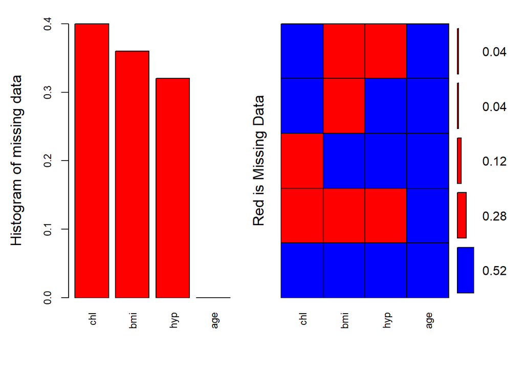

```
##
##  Variables sorted by number of missings:
##  Variable Count
##       chl  0.40
##       bmi  0.36
##       hyp  0.32
##       age  0.00
```

```r
VIM::aggr(nhanes, col=c('blue','red'), numbers = TRUE, sortVars = TRUE,
                  labels = names(nhanes), cex.axis = .8, gap = 3,
                  ylab = c("Histogram of missing data", "Red is Missing Data"))
```

```r
pattern <- mice::md.pattern(nhanes)
```

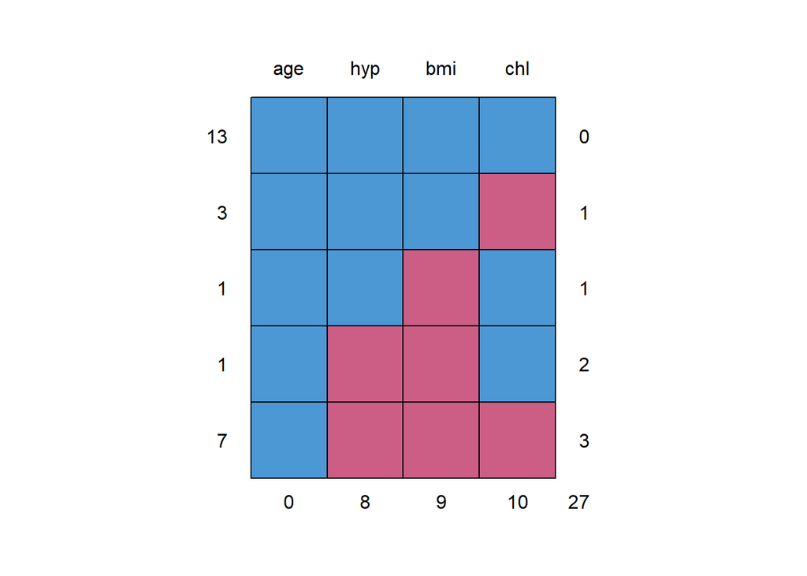

```r
pattern
```

```
##    age hyp bmi chl
## 13   1   1   1   1  0
## 3    1   1   1   0  1
## 1    1   1   0   1  1
## 1    1   0   0   1  2
## 7    1   0   0   0  3
##      0   8   9  10 27
```

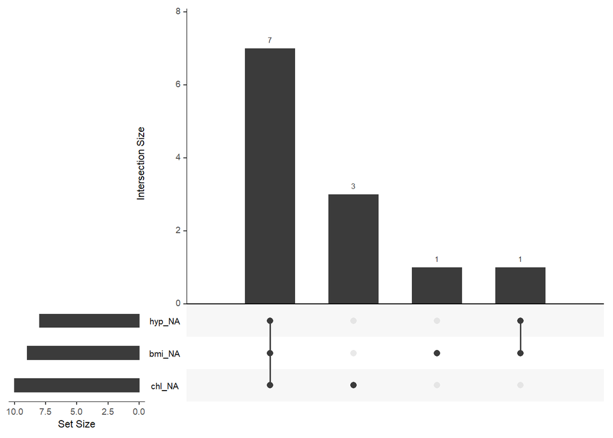

```r
naniar::gg_miss_upset(nhanes)
```

# Imputation methods

## Specifying models in `simputation`

Common structure for specifying an imputation model:

```r
impute_<model>(data, formula, [model-specific options])
```

Structure of the model in `formula`:

```r
IMPUTED ~ MODEL_SPECIFICATION [ | GROUPING ]
```

## Regression imputation

```r
imp_1 <- impute_lm(nhanes, bmi ~ age + hyp + chl)
head(imp_1)
```

```
##   age      bmi hyp chl
## 1   1       NA  NA  NA
## 2   2 22.70000   1 187
## 3   1 29.63182   1 187
## 4   3       NA  NA  NA
## 5   1 20.40000   1 113
## 6   3       NA  NA 184
```

```r
head(nhanes)
```

```
##   age  bmi hyp chl
## 1   1   NA  NA  NA
## 2   2 22.7   1 187
## 3   1   NA   1 187
## 4   3   NA  NA  NA
## 5   1 20.4   1 113
## 6   3   NA  NA 184
```

## Median imputation

```r
imp_2 <- simputation::impute_median(imp_1, bmi ~ age)
head(imp_2)
```

```
##   age      bmi hyp chl
## 1   1 29.61591  NA  NA
## 2   2 22.70000   1 187
## 3   1 29.63182   1 187
## 4   3 25.20000  NA  NA
## 5   1 20.40000   1 113
## 6   3 25.20000  NA 184
```

```r
imp_2a <- nhanes %>%
          simputation::impute_lm(bmi ~ age + hyp + chl) %>%
          simputation::impute_median(bmi ~ age)
head(imp_2a)
```

```
##   age      bmi hyp chl
## 1   1 29.61591  NA  NA
## 2   2 22.70000   1 187
## 3   1 29.63182   1 187
## 4   3 25.20000  NA  NA
## 5   1 20.40000   1 113
## 6   3 25.20000  NA 184
```

## Other methods

- `impute_cart()`: decision tree imputation
- `impute_hotdeck()`: random and sequential hot deck, k-nearest neighbours imputation and predictive mean matching.
- `impute_multivariate()`: imputation based on EM-estimation of multivariate normal parameters, imputation based on iterative Random Forest estimates and stochastic imptuation based on bootstrapped EM-estimatin of multivariate normal parameters.
- `impute_proxy()`: Impute missing values by a constant, by copying another variable, computing transformations from other variables.

## Multivariate Imputation by Chained Equations (mice)

Default imputation

```r
imp <- mice(nhanes, print = FALSE)
```

Defaults:

- pmm, predictive mean matching (numeric data)
- logreg, logistic regression imputation (binary data, factor with 2 levels)
- polyreg, polytomous regression imputation (unordered cateogrical data, factor > 2 levels)
- polr, proportional odds model (ordered data, factor > 2 levels)

## Check imputations

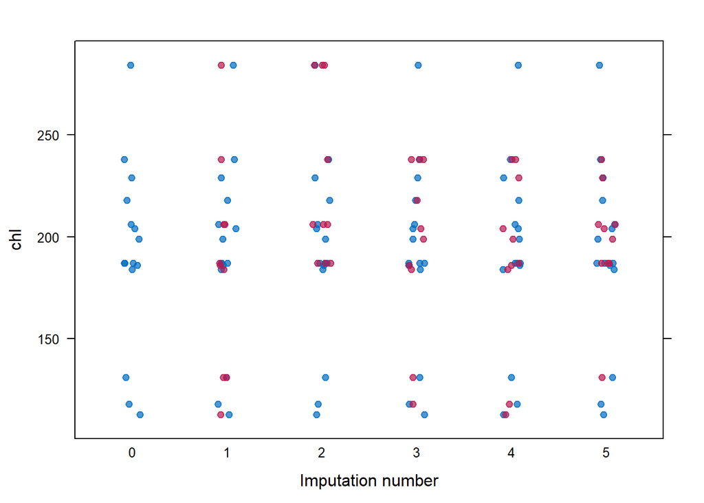

```r
stripplot(imp, chl, pch = 19, xlab = "Imputation number")
```

## Vary number of imputations

Just 4 imputed datasets instead of the default (5)

```r
imp <- mice(nhanes, m = 4, print = F)
```

## Predictor matrix

```r
imp$pred
```

```
##     age bmi hyp chl
## age   0   1   1   1
## bmi   1   0   1   1
## hyp   1   1   0   1
## chl   1   1   1   0
```

1 = column used to impute row

## Initial predictor matrix

```r
ini <- mice(nhanes, maxit = 0, print = F)
pred <- ini$pred
pred
```

```
##     age bmi hyp chl
## age   0   1   1   1
## bmi   1   0   1   1
## hyp   1   1   0   1
## chl   1   1   1   0
```

## Change predictor matrix

We do not use `hyp` to impute any other variables

```r
pred[ ,"hyp"] <- 0
pred
```

```
##     age bmi hyp chl
## age   0   1   0   1
## bmi   1   0   0   1
## hyp   1   1   0   1
## chl   1   1   0   0
```

```r
imp <- mice(nhanes, m = 4, init = pred, print = F)
```

## Changing imputation methods

```r
imp$meth
```

```
##   age   bmi   hyp   chl
##    "" "pmm" "pmm" "pmm"
```

```r
str(nhanes)
```

```
## 'data.frame':    25 obs. of  4 variables:
##  $ age: num  1 2 1 3 1 3 1 1 2 2 ...
##  $ bmi: num  NA 22.7 NA NA 20.4 NA 22.5 30.1 22 NA ...
##  $ hyp: num  NA 1 1 NA 1 NA 1 1 1 NA ...
##  $ chl: num  NA 187 187 NA 113 184 118 187 238 NA ...
```

```r
str(nhanes2)
```

```
## 'data.frame':    25 obs. of  4 variables:
##  $ age: Factor w/ 3 levels "20-39","40-59",..: 1 2 1 3 1 3 1 1 2 2 ...
##  $ bmi: num  NA 22.7 NA NA 20.4 NA 22.5 30.1 22 NA ...
##  $ hyp: Factor w/ 2 levels "no","yes": NA 1 1 NA 1 NA 1 1 1 NA ...
##  $ chl: num  NA 187 187 NA 113 184 118 187 238 NA ...
```

```r
imp <- mice(nhanes2, m = 4, init = pred, print = F, seed = 101)
imp$meth
```

```
##      age      bmi      hyp      chl
##       ""    "pmm" "logreg"    "pmm"
```

## Available methods

```r
methods(mice)
```

```
##  [1] mice.impute.2l.bin       mice.impute.2l.lmer
##  [3] mice.impute.2l.norm      mice.impute.2l.pan
##  [5] mice.impute.2lonly.mean  mice.impute.2lonly.norm
##  [7] mice.impute.2lonly.pmm   mice.impute.cart
##  [9] mice.impute.jomoImpute   mice.impute.lda
## [11] mice.impute.logreg       mice.impute.logreg.boot
## [13] mice.impute.mean         mice.impute.midastouch
## [15] mice.impute.norm         mice.impute.norm.boot
## [17] mice.impute.norm.nob     mice.impute.norm.predict
## [19] mice.impute.panImpute    mice.impute.passive
## [21] mice.impute.pmm          mice.impute.polr
## [23] mice.impute.polyreg      mice.impute.quadratic
## [25] mice.impute.rf           mice.impute.ri
## [27] mice.impute.sample       mice.mids
## [29] mice.theme
## see '?methods' for accessing help and source code
```

## Extracting imputed data

The 3rd imputed dataset

```r
c3 <- complete(imp, 3)
md.pattern(c3, plot = FALSE)
```

```
##  /\     /\
## {  `---'  }
## {  O   O  }
## ==>  V <==  No need for mice. This data set is completely observed.
##  \  \|/  /
##   `-----'
```

```
##    age bmi hyp chl
## 25   1   1   1   1 0
##      0   0   0   0 0
```

All imputed datasets in long format

```r
complete(imp, "long")
```

```
##     .imp .id   age  bmi hyp chl
## 1      1   1 20-39 30.1  no 238
## 2      1   2 40-59 22.7  no 187
## 3      1   3 20-39 27.2  no 187
## 4      1   4 60-99 22.0  no 184
## 5      1   5 20-39 20.4  no 113
## 6      1   6 60-99 27.5 yes 184
## 7      1   7 20-39 22.5  no 118
## 8      1   8 20-39 30.1  no 187
## 9      1   9 40-59 22.0  no 238
## 10     1  10 40-59 22.5 yes 187
## 11     1  11 20-39 33.2  no 238
## 12     1  12 40-59 20.4  no 229
## 13     1  13 60-99 21.7  no 206
## 14     1  14 40-59 28.7 yes 204
```

[output cut: 86 more lines]

## Pooling analyses

```r
fit <- with(imp, lm(bmi ~ chl))
fit
```

```
## call :
## with.mids(data = imp, expr = lm(bmi ~ chl))
##
## call1 :
## mice(data = nhanes2, m = 4, printFlag = F, seed = 101, init = pred)
##
## nmis :
## age bmi hyp chl
##   0   9   8  10
##
## analyses :
## [[1]]
##
## Call:
## lm(formula = bmi ~ chl)
##
## Coefficients:
## (Intercept)          chl
##    22.15053      0.02338
##
##
## [[2]]
##
## Call:
## lm(formula = bmi ~ chl)
##
## Coefficients:
## (Intercept)          chl
##     19.9017       0.0367
##
##
## [[3]]
##
## Call:
## lm(formula = bmi ~ chl)
##
## Coefficients:
## (Intercept)          chl
##     20.2657       0.0371
##
##
## [[4]]
##
## Call:
## lm(formula = bmi ~ chl)
##
## Coefficients:
## (Intercept)          chl
##    19.04484      0.04203
```

```r
summary(fit$analyses[[2]])
```

```
##
## Call:
## lm(formula = bmi ~ chl)
##
## Residuals:
##     Min      1Q  Median      3Q     Max
## -6.6367 -3.6490 -0.3548  2.8947  7.3974
##
## Coefficients:
##             Estimate Std. Error t value Pr(>|t|)
## (Intercept) 19.90171    4.98265   3.994 0.000571 ***
## chl          0.03670    0.02496   1.470 0.155057
## ---
## Signif. codes:  0 '***' 0.001 '**' 0.01 '*' 0.05 '.' 0.1 ' ' 1
##
## Residual standard error: 4.549 on 23 degrees of freedom
## Multiple R-squared:  0.0859, Adjusted R-squared:  0.04616
## F-statistic: 2.161 on 1 and 23 DF,  p-value: 0.1551
```

```r
pool.fit <- pool(fit)
summary(pool.fit)
```

```
##                estimate  std.error statistic       df      p.value
## (Intercept) 20.34068248 4.54833393  4.472117 17.81040 0.0003016604
## chl          0.03480344 0.02379386  1.462707 16.27191 0.1625944773
```

## Other packages for imputation

- `mi`
- `Hmisc`
- `Amelia`
- `mix`

# Extra slides

## Visualization

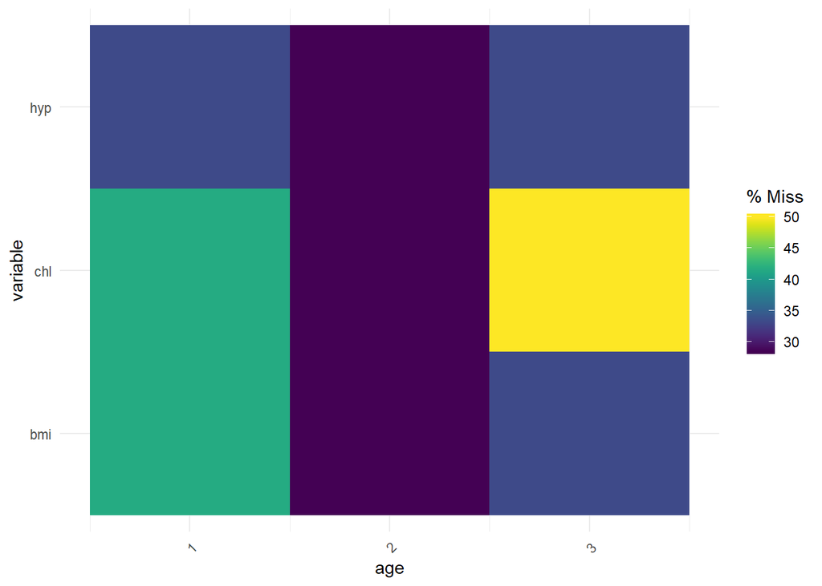

```r
naniar::gg_miss_fct(x = nhanes, fct = age)
```

## Visualization

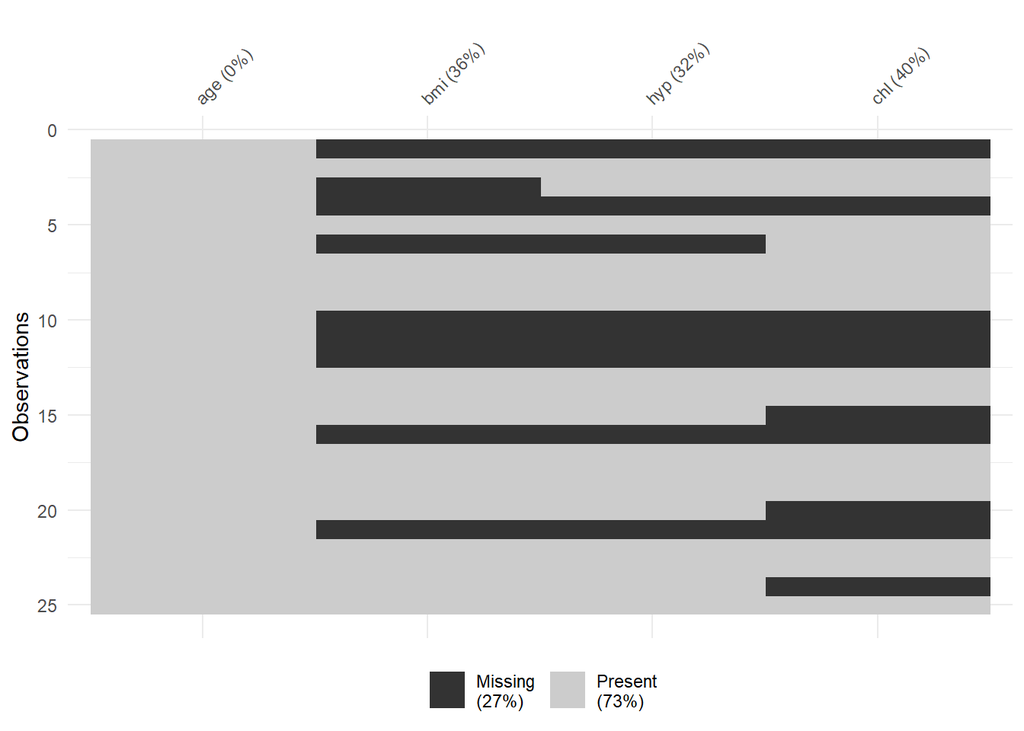

```r
visdat::vis_miss(nhanes)
```

## Convergence

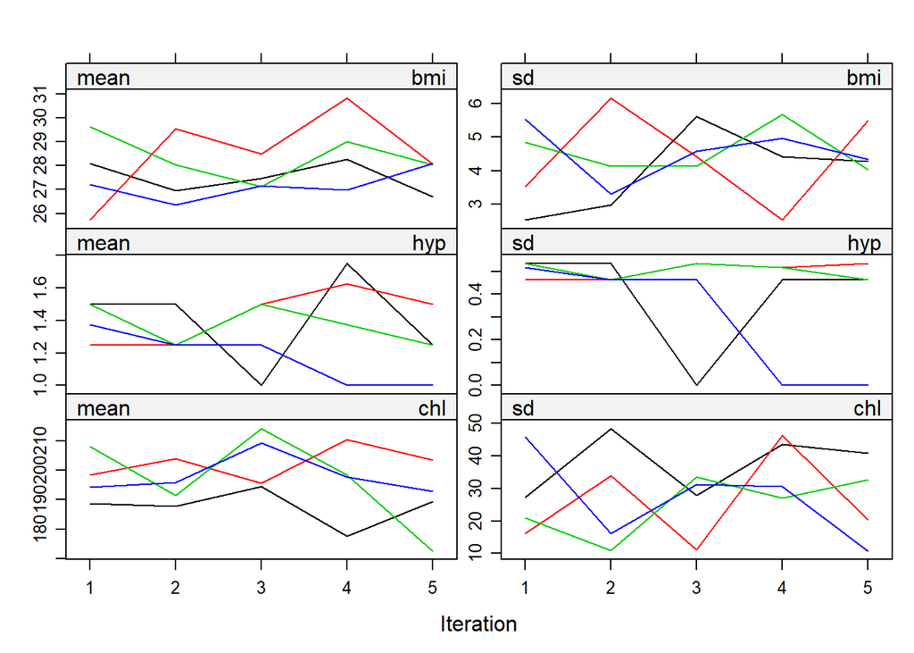

```r
plot(imp)
```

## Seed values

```r
imp <- mice(nhanes, m = 4, init = pred, print = F, seed = 101)
```